# Analysing the Waitlist and Decline Groups

## Overview of Waitlist vs Decline Groups

After exploring some of the trends between students who were admitted versus students who were declined or waitlisted, we felt it was also important to look more at what the difference was between a student getting declined or waitlisted. First, here are the differences between the averages of all of the testing scores, GPA, volunteer levels, and work experience between these two groups.

| Decision | GPA | Work Experience | Test Score | Writing Score | Volunteer Level |
| --- | --- | --- | --- | --- | --- |
| Decline | 3.252500 | 2.200000 | 780.1071 | 74.14286 | 2.571429 |
| Waitlist | 3.486522 | 2.213043 | 865.6957 | 82.52174 | 2.608696 |

From this table, we can see the students on the waitlist have higher scores in each categories. There appear to be bigger differences between GPA, Test Scores, and Writing Scores, than in work experience and volunteer level. We can do a statistical test to test for a difference in means.

| Variable | p-value |
| --- | --- |
| GPA | 0.002 |
| WorkExp | 0.978 |
| TestScore | < 0.001 |
| WritingScore | < 0.001 |
| VolunteerLevel | 0.938 |

From this test, we see that there is a statistically significant difference in means between the decline and waitlist groups in GPA, Test Score, and Writing Score. These are the variables we will explore further to see how different they are between the waitlist/decline groups.

## Exploring Significant Variables

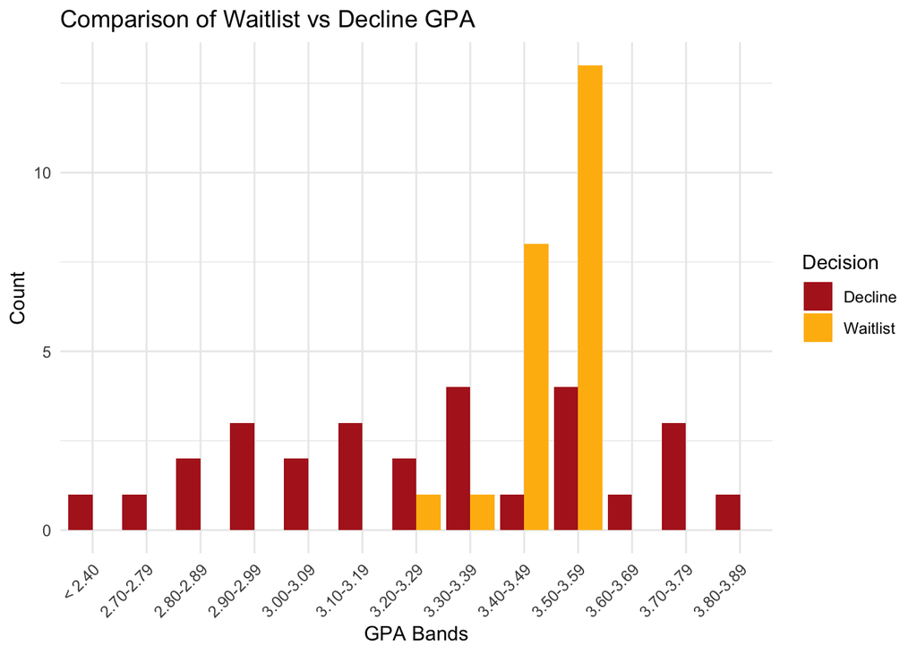

In terms of GPA, we see that the waitlisted students’ GPAs range between 3.20 and 3.59, whereas the declined students’ GPAs are across the board.

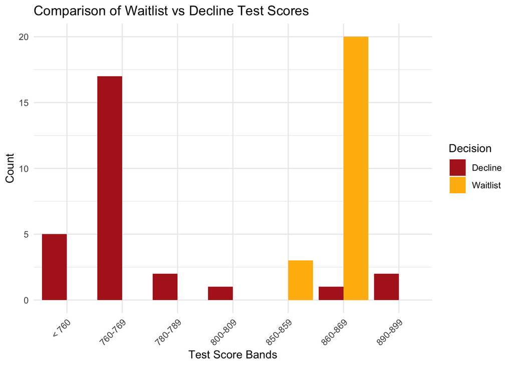

In this exploration of the test scores for waitlisted and declined students, we see that declined students tended to have lower test scores, with scores typically being below 800, whereas all waitlisted students had scores between 850-870.

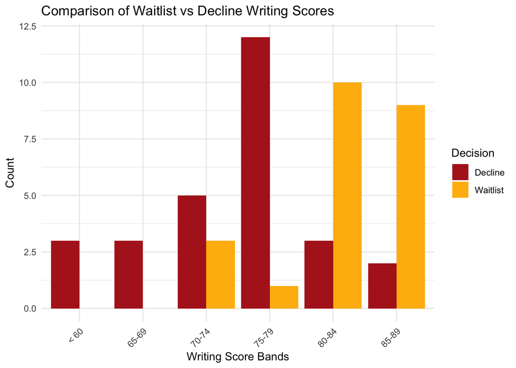

We see a similar trend in the writing scores, with declined students typically having scores lower than 80 and waitlisted students typically having scores above 80.

It is important to note that there are students who have been declined who have higher GPAs, test scores, and writing scores than many of the waitlisted students. Why may that be? Let’s explore this trend further below.

## Case Study

Have a look at the following three candidates.

Candidate 1:

| Decision | State | GPA | WorkExp | TestScore | WritingScore | Gender | VolunteerLevel |
| --- | --- | --- | --- | --- | --- | --- | --- |
| Decline | Florida | 3.84 | 2.7 | 896 | 89 | 1 | 1 |

Candidate 2:

| Decision | State | GPA | WorkExp | TestScore | WritingScore | Gender | VolunteerLevel |
| --- | --- | --- | --- | --- | --- | --- | --- |
| Admit | Florida | 3.8 | 1.4 | 969 | 97 | 1 | 4 |

Candidate 3:

| Decision | State | GPA | WorkExp | TestScore | WritingScore | Gender | VolunteerLevel |
| --- | --- | --- | --- | --- | --- | --- | --- |
| Waitlist | Utah | 3.58 | 0.9 | 864 | 82 | 1 | 5 |